# comparison of legislative texts

## distinctivity of words

Creation of the merged data frame.

```r
library(dplyr)
# Add a new column named "country" with the value "Italy" to testoit_df
testoit_df_principles <- testoit_df_principles %>%
  mutate(country = "Italy")
testoSA_df <- testoSA_df %>%
  mutate(country = "South Africa")
testoes_df_principles <- testoes_df_principles %>%
  mutate(country = "Spain")
testoUSA_df <- testoUSA_df |>
  mutate(country = "USA")
  testoue_df<- testoue_df |> mutate(country= " European union")

merged_df <- bind_rows(testoit_df_principles, testoSA_df, testoes_df_principles, testoUSA_df, testoue_df)
```

Analysis of the frequence by rank.

```r
# Group by word and country, calculate the frequency of each word-country pair,
# and then ungroup the dataframe
merged_df <- merged_df %>%
  group_by(word, country) %>%
  summarise(n = n()) %>%
  ungroup()
```

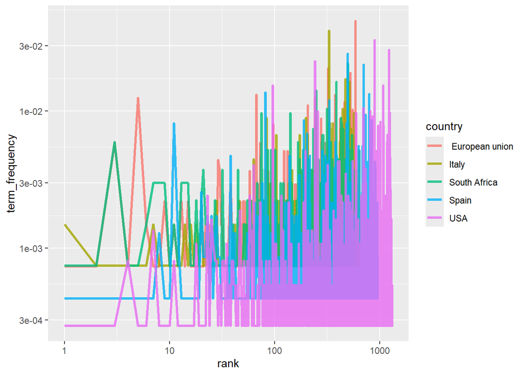

```r
# Group by country, calculate the term frequency of each word within each country
merged_df <- merged_df %>%
  group_by(country) %>%
  mutate(term_frequency = n / sum(n))

# Group by country, calculate the rank of each word within each country,
# and then ungroup the dataframe
freq_by_rank <- merged_df %>%
  group_by(country) %>%
  mutate(rank = row_number()) %>%
  ungroup()

# Plot the term frequency by rank for each country
freq_by_rank %>%
  ggplot(aes(rank, term_frequency, color = country)) +
  # Plot settings
  geom_line(linewidth = 1.1, alpha = 0.8, show.legend = TRUE) +
  scale_x_log10() +
  scale_y_log10()
```

As the frequency of words increases, the rank moves away from the top places. ## The tf-idf!

The tf-idf weight function is a function used in information retrieval to measure the importance of a term relative to a collection of documents.

```r
law_tf_idf <- merged_df %>%
  bind_tf_idf(word, country, n)

law_tf_idf
```

```
## # A tibble: 4,104 × 7
## # Groups:   country [5]
##    word        country     n term_frequency       tf   idf   tf_idf
##    <chr>       <chr>   <int>          <dbl>    <dbl> <dbl>    <dbl>
##  1 abdicated   USA         1       0.000271 0.000271  1.61 0.000436
##  2 abdications Spain       1       0.000431 0.000431  1.61 0.000693
##  3 ability     USA         1       0.000271 0.000271  1.61 0.000436
##  4 abolish     USA         1       0.000271 0.000271  1.61 0.000436
##  5 abolished   Spain       1       0.000431 0.000431  1.61 0.000693
##  6 abolishing  USA         3       0.000813 0.000813  1.61 0.00131
##  7 abra        USA         1       0.000271 0.000271  1.61 0.000436
##  8 abridge     USA         1       0.000271 0.000271  1.61 0.000436
##  9 abridged    USA         5       0.00135  0.00135   1.61 0.00218
## 10 abridging   USA         1       0.000271 0.000271  1.61 0.000436
## # ℹ 4,094 more rows
```

In the previous chunk the numerical values are computed, but the best way to see and understand them, it’s graphically

```r
law_tf_idf %>%
  #we arrange by tf-idf in descending order
  arrange(desc(tf_idf))
```

```
## # A tibble: 4,104 × 7
## # Groups:   country [5]
##    word      country               n term_frequency      tf   idf tf_idf
##    <chr>     <chr>             <int>          <dbl>   <dbl> <dbl>  <dbl>
##  1 united    "USA"               104        0.0282  0.0282  1.61  0.0453
##  2 president "USA"               122        0.0330  0.0330  0.916 0.0303
##  3 congress  "USA"                86        0.0233  0.0233  0.916 0.0213
##  4 charter   " European union"    18        0.0132  0.0132  1.61  0.0213
##  5 european  " European union"    15        0.0110  0.0110  1.61  0.0178
##  6 house     "USA"                36        0.00975 0.00975 1.61  0.0157
##  7 vice      "USA"                36        0.00975 0.00975 1.61  0.0157
##  8 republic  "Italy"              22        0.0164  0.0164  0.916 0.0150
##  9 spain     "Spain"              20        0.00861 0.00861 1.61  0.0139
## 10 cortes    "Spain"              16        0.00689 0.00689 1.61  0.0111
## # ℹ 4,094 more rows
```

The graphs

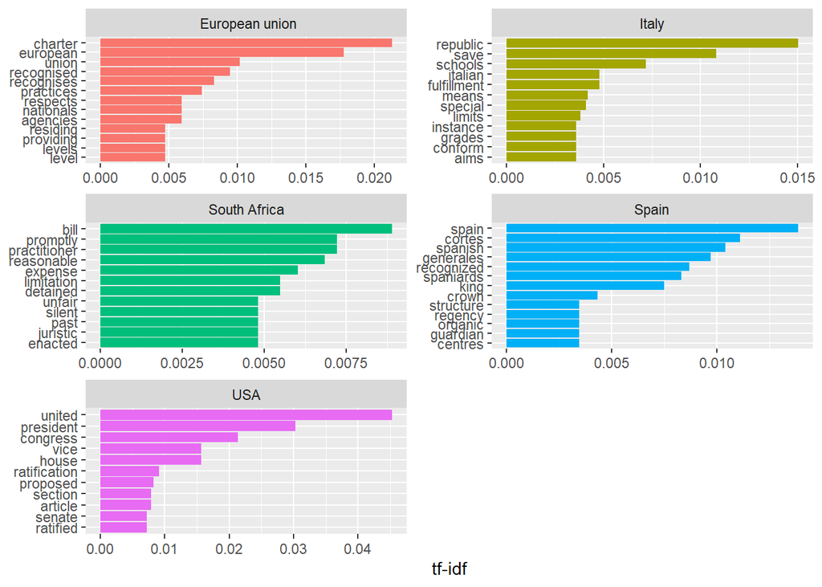

```r
library(forcats)

law_tf_idf %>%
  group_by(country) %>%
  #choose maximum number of words
  slice_max(tf_idf, n = 10) %>%
  ungroup() %>%
  ggplot(aes(tf_idf, fct_reorder(word, tf_idf), fill = country)) +
  geom_col(show.legend = FALSE) +
  facet_wrap(~country, ncol = 2, scales = "free") +
  labs(x = "tf-idf", y = NULL)
```

I would like to specify that I am aware that the European Union is not a country, the use of the term “country” in this case is improper and has only a functional purpose.

Italy is recognized by terms such as “school,” “fulfillment,” and “republic.” I was surprised by the word “school,” apparently in other legal texts it plays a less prominent role.

The South African text retains in its distintino aspect the “past” and somewhat obscure words that explain its history: “unfair” and “silent.”

The U.S. text summarizes the country’s political power.

## Sparsity

```r
calculate_sparsity <- function(df) {
  library(dplyr)

  # Count the frequency of each word
  word_counts <- df %>%
    count(word)

  # Calculate the total number of words
  total_words <- sum(word_counts$n)

  # Calculate the number of unique words
  unique_words <- nrow(word_counts)

  # Calculate the sparsity
  sparsity <- 1 - (unique_words / total_words)

  # Return the sparsity value
  return(sparsity)
}
```

```r
calculate_sparsity(testoes_df)
```

```
## [1] 0.7512345
```

```r
calculate_sparsity(testoit_df)
```

```
## [1] 0.6836915
```

```r
calculate_sparsity(testoSA_df)
```

```
## [1] 0.5695067
```

```r
calculate_sparsity(testoUSA_df)
```

```
## [1] 0.6432828
```

```r
calculate_sparsity(testoue_df)
```

```
## [1] 0.5518764
```

The analysis was very challenging for me to do, and I was able to learn a lot. I hope the results are worthwhile and can provide consistency.

-Nadia